# Stata’s `margins` command in R

One of Stata’s major strengths is the [`margins`](https://www.stata.com/manuals/rmargins.pdf) command, a model post-estimation command which enables users to quickly and easily obtain marginal means and slopes, investigate interaction effects, and, via [`marginsplot`](https://www.stata.com/manuals/rmarginsplot.pdf), visualize said effects, especially interaction plots.

I frequently find it frustrating coming to R and not having margins, so this document will demostrate how to get equivalent results out of R.

In the R code, the following packages are used.

```r
library(emmeans)
library(interactions)
```

# Load data

We’ll use a data set built into Stata, `margex`, which they use for a lot of margin examples. In Stata we can simply load it; R will have to import it via the `haven` library.

## Stata

```
##
## . quiet webuse mar.
## .
```

## R

```r
library(haven)
m <- haven::read_dta("http://www.stata-press.com/data/r15/margex.dta")
m$sex <- as_factor(m$sex)
m$group <- as_factor(m$group)
```

# Marginal Means

Marginal means are statistics calculated from predicted values of a model at fixed values of covariates.

## Categorical Variable

When we have a single categorical variable (not involved in an interaction), one level is excluded as a reference or baseline category, and the coefficients on the other levels represent the average difference between those levels and the reference.

### Stata

```
##
## . quiet webuse mar. regress y i.group
##
##       Source |       SS           df       MS      Number of obs   =     3,000
## -------------+----------------------------------   F(2, 2997)      =     15.48
##        Model |  14229.0349         2  7114.51743   Prob > F        =    0.0000
##     Residual |  1377203.97     2,997  459.527518   R-squared       =    0.0102
## -------------+----------------------------------   Adj R-squared   =    0.0096
##        Total |  1391433.01     2,999  463.965657   Root MSE        =    21.437
##
## ------------------------------------------------------------------------------
##            y |      Coef.   Std. Err.      t    P>|t|     [95% Conf. Interval]
## -------------+----------------------------------------------------------------
##        group |
##           2  |   .4084991   .8912269     0.46   0.647    -1.338979    2.155977
##           3  |   5.373138   1.027651     5.23   0.000     3.358165     7.38811
##        _cons |   68.35805   .6190791   110.42   0.000     67.14419    69.57191
## ------------------------------------------------------------------------------
##
## . margins group
##
## Adjusted predictions                            Number of obs     =      3,000
## Model VCE    : OLS
##
## Expression   : Linear prediction, predict()
##
## ------------------------------------------------------------------------------
##              |            Delta-method
##              |     Margin   Std. Err.      t    P>|t|     [95% Conf. Interval]
## -------------+----------------------------------------------------------------
##        group |
##           1  |   68.35805   .6190791   110.42   0.000     67.14419    69.57191
##           2  |   68.76655   .6411134   107.26   0.000     67.50948    70.02361
##           3  |   73.73119   .8202484    89.89   0.000     72.12288    75.33949
## ------------------------------------------------------------------------------
##
## .
```

### R

```r
summary(mod1 <- lm(y ~ group, data = m))
```

```
##
## Call:
## lm(formula = y ~ group, data = m)
##
## Residuals:
##     Min      1Q  Median      3Q     Max
## -73.531 -14.758   0.101  14.536  72.569
##
## Coefficients:
##             Estimate Std. Error t value Pr(>|t|)
## (Intercept)  68.3580     0.6191 110.419  < 2e-16 ***
## group2        0.4085     0.8912   0.458    0.647
## group3        5.3731     1.0277   5.229 1.83e-07 ***
## ---
## Signif. codes:  0 '***' 0.001 '**' 0.01 '*' 0.05 '.' 0.1 ' ' 1
##
## Residual standard error: 21.44 on 2997 degrees of freedom
## Multiple R-squared:  0.01023,    Adjusted R-squared:  0.009566
## F-statistic: 15.48 on 2 and 2997 DF,  p-value: 2.045e-07
```

```r
emmeans::emmeans(mod1, ~ group)
```

```
##  group emmean    SE   df lower.CL upper.CL
##  1       68.4 0.619 2997     67.1     69.6
##  2       68.8 0.641 2997     67.5     70.0
##  3       73.7 0.820 2997     72.1     75.3
##
## Confidence level used: 0.95
```

### Math

Assume a linear regression set up with a single categorical variable, $G$, with three groups. We fit

$$E(Y|G) = \beta_0 + \beta_1g_2 + \beta_2g_3,$$

where $g_2$ and $g_3$ are dummy variables representing membership in groups 2 and 3 respectively ($g_{2i} = 1$ if observation $i$ has $G = 2$, and equal to 0 otherwise.) Since $g_1$ is not found in the model, it is the reference category.

Therefore, $\beta_0$ represents the average response among the reference category $G = 1$. $\beta_1$ represents the difference in the average response between groups $G = 1$ and $G = 2$. Therefore, $\beta_0 + \beta_1$ is the average response in group $G = 2$. A similar argument can be made about $\beta_2$ and group 3.

## Categorical Variables & Interactions

When we have an interaction of categorical variables, we can estimate the marginal mean in each combination of levels from the two categorical variables.

Alternatively,

**To do: `atmeans` versus as observed - I believe `emmeans` default is `atmeans` while Stata’s is as observed.**

### Stata

```
##
## . quiet webuse mar. regress y i.sex##i.group
##
##       Source |       SS           df       MS      Number of obs   =     3,000
## -------------+----------------------------------   F(5, 2994)      =     92.91
##        Model |  186898.199         5  37379.6398   Prob > F        =    0.0000
##     Residual |  1204534.81     2,994  402.316235   R-squared       =    0.1343
## -------------+----------------------------------   Adj R-squared   =    0.1329
##        Total |  1391433.01     2,999  463.965657   Root MSE        =    20.058
##
## ------------------------------------------------------------------------------
##            y |      Coef.   Std. Err.      t    P>|t|     [95% Conf. Interval]
## -------------+----------------------------------------------------------------
##          sex |
##      female  |   21.62507   1.509999    14.32   0.000     18.66433    24.58581
##        group |
##           2  |   11.37444   1.573314     7.23   0.000     8.289552    14.45932
##           3  |    21.6188   1.588487    13.61   0.000     18.50416    24.73344
##    sex#group |
##    female#2  |  -4.851582   1.942744    -2.50   0.013     -8.66083   -1.042333
##    female#3  |  -6.084875   3.004638    -2.03   0.043    -11.97624   -.1935115
##        _cons |    50.6107   1.367932    37.00   0.000     47.92852    53.29288
## ------------------------------------------------------------------------------
##
## . margins sex
##
## Predictive margins                              Number of obs     =      3,000
## Model VCE    : OLS
##
## Expression   : Linear prediction, predict()
##
## ------------------------------------------------------------------------------
##              |            Delta-method
##              |     Margin   Std. Err.      t    P>|t|     [95% Conf. Interval]
## -------------+----------------------------------------------------------------
##          sex |
##        male  |   59.77145   .6454388    92.61   0.000      58.5059      61.037
##      female  |   78.20318   .7105463   110.06   0.000     76.80997    79.59639
## ------------------------------------------------------------------------------
##
## . margins sex#group
##
## Adjusted predictions                            Number of obs     =      3,000
## Model VCE    : OLS
##
## Expression   : Linear prediction, predict()
##
## ------------------------------------------------------------------------------
##              |            Delta-method
##              |     Margin   Std. Err.      t    P>|t|     [95% Conf. Interval]
## -------------+----------------------------------------------------------------
##    sex#group |
##      male#1  |    50.6107   1.367932    37.00   0.000     47.92852    53.29288
##      male#2  |   61.98514   .7772248    79.75   0.000     60.46119    63.50908
##      male#3  |    72.2295   .8074975    89.45   0.000     70.64619     73.8128
##    female#1  |   72.23577     .63942   112.97   0.000     70.98203    73.48952
##    female#2  |   78.75863   .9434406    83.48   0.000     76.90877    80.60849
##    female#3  |    87.7697   2.468947    35.55   0.000     82.92869     92.6107
## ------------------------------------------------------------------------------
##
## .
```

### R

```r
summary(mod1 <- lm(y ~ sex*group, data = m))
```

```
##
## Call:
## lm(formula = y ~ sex * group, data = m)
##
## Residuals:
##     Min      1Q  Median      3Q     Max
## -72.029 -13.285   0.464  13.741  67.964
##
## Coefficients:
##                  Estimate Std. Error t value Pr(>|t|)
## (Intercept)        50.611      1.368  36.998  < 2e-16 ***
## sexfemale          21.625      1.510  14.321  < 2e-16 ***
## group2             11.374      1.573   7.230 6.12e-13 ***
## group3             21.619      1.588  13.610  < 2e-16 ***
## sexfemale:group2   -4.852      1.943  -2.497   0.0126 *
## sexfemale:group3   -6.085      3.005  -2.025   0.0429 *
## ---
## Signif. codes:  0 '***' 0.001 '**' 0.01 '*' 0.05 '.' 0.1 ' ' 1
##
## Residual standard error: 20.06 on 2994 degrees of freedom
## Multiple R-squared:  0.1343, Adjusted R-squared:  0.1329
## F-statistic: 92.91 on 5 and 2994 DF,  p-value: < 2.2e-16
```

```r
emmeans::emmeans(mod1, ~ group)
```

```
## NOTE: Results may be misleading due to involvement in interactions
```

```
##  group emmean    SE   df lower.CL upper.CL
##  1       61.4 0.755 2994     59.9     62.9
##  2       70.4 0.611 2994     69.2     71.6
##  3       80.0 1.299 2994     77.5     82.5
##
## Results are averaged over the levels of: sex
## Confidence level used: 0.95
```

```r
emmeans::emmeans(mod1, ~ group + sex)
```

```
##  group sex    emmean    SE   df lower.CL upper.CL
##  1     male     50.6 1.368 2994     47.9     53.3
##  2     male     62.0 0.777 2994     60.5     63.5
##  3     male     72.2 0.807 2994     70.6     73.8
##  1     female   72.2 0.639 2994     71.0     73.5
##  2     female   78.8 0.943 2994     76.9     80.6
##  3     female   87.8 2.469 2994     82.9     92.6
##
## Confidence level used: 0.95
```

### Math

Consider the simplest case, with two binary variables $Z$ and $K$. We fit the model

$$E(Y|Z,K) = \beta_0 + \beta_1Z + \beta_2K + \beta_3ZK,$$

This is functionally equivalent to defining a new variable $L$,

$$L = \begin{cases}
0, & K = 0 \& Z = 0 \\
1, & K = 0 \& Z = 1 \\
2, & K = 1 \& Z = 0 \\
3, & K = 1 \& Z = 1,
\end{cases}$$

and fitting the model

$$E(Y|L) = \beta_0 + \beta_1l_1 + \beta_2l_2 + \beta_3l_3.$$

## Catergorical Variables and Continuous Variables

When there are additional continuous variables in the model, we may wish to obtain the marginal mean at specified levels of the continuous variable.

### Stata

```
##
## . quiet webuse mar. regress y i.sex c.age
##
##       Source |       SS           df       MS      Number of obs   =     3,000
## -------------+----------------------------------   F(2, 2997)      =    209.88
##        Model |  170938.657         2  85469.3283   Prob > F        =    0.0000
##     Residual |  1220494.35     2,997  407.238688   R-squared       =    0.1229
## -------------+----------------------------------   Adj R-squared   =    0.1223
##        Total |  1391433.01     2,999  463.965657   Root MSE        =     20.18
##
## ------------------------------------------------------------------------------
##            y |      Coef.   Std. Err.      t    P>|t|     [95% Conf. Interval]
## -------------+----------------------------------------------------------------
##          sex |
##      female  |   14.03271   .7777377    18.04   0.000     12.50775    15.55766
##          age |  -.5043666    .033698   -14.97   0.000    -.5704402   -.4382931
##        _cons |   82.78115   1.323613    62.54   0.000     80.18586    85.37643
## ------------------------------------------------------------------------------
##
## . margins sex, at(age = (30 40))
##
## Adjusted predictions                            Number of obs     =      3,000
## Model VCE    : OLS
##
## Expression   : Linear prediction, predict()
##
## 1._at        : age             =          30
##
## 2._at        : age             =          40
##
## ------------------------------------------------------------------------------
##              |            Delta-method
##              |     Margin   Std. Err.      t    P>|t|     [95% Conf. Interval]
## -------------+----------------------------------------------------------------
##      _at#sex |
##      1#male  |   67.65015   .5604889   120.70   0.000     66.55116    68.74913
##    1#female  |   81.68285   .6911128   118.19   0.000     80.32775    83.03796
##      2#male  |   62.60648    .537682   116.44   0.000     61.55222    63.66074
##    2#female  |   76.63919    .533784   143.58   0.000     75.59257    77.68581
## ------------------------------------------------------------------------------
##
## .
```

### R

For each unique level of the continuous variable, a seperate `emmeans` call is needed apparently. If anyone knows a way around this, please let me know.

```r
summary(mod1 <- lm(y ~ sex + age, data = m))
```

```
##
## Call:
## lm(formula = y ~ sex + age, data = m)
##
## Residuals:
##    Min     1Q Median     3Q    Max
## -71.99 -13.88  -0.15  13.76  75.28
##
## Coefficients:
##             Estimate Std. Error t value Pr(>|t|)
## (Intercept)  82.7811     1.3236   62.54   <2e-16 ***
## sexfemale    14.0327     0.7777   18.04   <2e-16 ***
## age          -0.5044     0.0337  -14.97   <2e-16 ***
## ---
## Signif. codes:  0 '***' 0.001 '**' 0.01 '*' 0.05 '.' 0.1 ' ' 1
##
## Residual standard error: 20.18 on 2997 degrees of freedom
## Multiple R-squared:  0.1229, Adjusted R-squared:  0.1223
## F-statistic: 209.9 on 2 and 2997 DF,  p-value: < 2.2e-16
```

```r
emmeans::emmeans(mod1, ~ sex, at = list(age = 30))
```

```
##  sex    emmean    SE   df lower.CL upper.CL
##  male     67.7 0.560 2997     66.6     68.7
##  female   81.7 0.691 2997     80.3     83.0
##
## Confidence level used: 0.95
```

```r
emmeans::emmeans(mod1, ~ sex, at = list(age = 40))
```

```
##  sex    emmean    SE   df lower.CL upper.CL
##  male     62.6 0.538 2997     61.6     63.7
##  female   76.6 0.534 2997     75.6     77.7
##
## Confidence level used: 0.95
```

## Catergorical Variables & Continuous Variable Interaction

### Stata

```
##
## . quiet webuse mar. regress y i.sex##c.age
##
##       Source |       SS           df       MS      Number of obs   =     3,000
## -------------+----------------------------------   F(3, 2996)      =    139.91
##        Model |  170983.675         3  56994.5583   Prob > F        =    0.0000
##     Residual |  1220449.33     2,996   407.35959   R-squared       =    0.1229
## -------------+----------------------------------   Adj R-squared   =    0.1220
##        Total |  1391433.01     2,999  463.965657   Root MSE        =    20.183
##
## ------------------------------------------------------------------------------
##            y |      Coef.   Std. Err.      t    P>|t|     [95% Conf. Interval]
## -------------+----------------------------------------------------------------
##          sex |
##      female  |   14.92308   2.789012     5.35   0.000     9.454508    20.39165
##          age |  -.4929608   .0480944   -10.25   0.000    -.5872622   -.3986595
##    sex#c.age |
##      female  |  -.0224116   .0674167    -0.33   0.740    -.1545994    .1097762
##        _cons |   82.36936   1.812958    45.43   0.000      78.8146    85.92413
## ------------------------------------------------------------------------------
##
## . margins sex, at(age = (30 40))
##
## Adjusted predictions                            Number of obs     =      3,000
## Model VCE    : OLS
##
## Expression   : Linear prediction, predict()
##
## 1._at        : age             =          30
##
## 2._at        : age             =          40
##
## ------------------------------------------------------------------------------
##              |            Delta-method
##              |     Margin   Std. Err.      t    P>|t|     [95% Conf. Interval]
## -------------+----------------------------------------------------------------
##      _at#sex |
##      1#male  |   67.58054   .5984013   112.94   0.000     66.40722    68.75386
##    1#female  |   81.83127   .8228617    99.45   0.000     80.21784     83.4447
##      2#male  |   62.65093   .5541361   113.06   0.000     61.56441    63.73746
##    2#female  |   76.67755   .5461908   140.39   0.000      75.6066    77.74849
## ------------------------------------------------------------------------------
##
## .
```

### R

```r
summary(mod1 <- lm(y ~ sex*age, data = m))
```

```
##
## Call:
## lm(formula = y ~ sex * age, data = m)
##
## Residuals:
##     Min      1Q  Median      3Q     Max
## -71.817 -13.848  -0.116  13.758  75.263
##
## Coefficients:
##               Estimate Std. Error t value Pr(>|t|)
## (Intercept)   82.36936    1.81296  45.434  < 2e-16 ***
## sexfemale     14.92308    2.78901   5.351 9.42e-08 ***
## age           -0.49296    0.04809 -10.250  < 2e-16 ***
## sexfemale:age -0.02241    0.06742  -0.332     0.74
## ---
## Signif. codes:  0 '***' 0.001 '**' 0.01 '*' 0.05 '.' 0.1 ' ' 1
##
## Residual standard error: 20.18 on 2996 degrees of freedom
## Multiple R-squared:  0.1229, Adjusted R-squared:  0.122
## F-statistic: 139.9 on 3 and 2996 DF,  p-value: < 2.2e-16
```

```r
emmeans::emmeans(mod1, ~ sex, at = list(age = 30))
```

```
## NOTE: Results may be misleading due to involvement in interactions
```

```
##  sex    emmean    SE   df lower.CL upper.CL
##  male     67.6 0.598 2996     66.4     68.8
##  female   81.8 0.823 2996     80.2     83.4
##
## Confidence level used: 0.95
```

```r
emmeans::emmeans(mod1, ~ sex, at = list(age = 40))
```

```
## NOTE: Results may be misleading due to involvement in interactions
```

```
##  sex    emmean    SE   df lower.CL upper.CL
##  male     62.7 0.554 2996     61.6     63.7
##  female   76.7 0.546 2996     75.6     77.7
##
## Confidence level used: 0.95
```

# Marginal Slopes

## No interaction

### Stata

```
##
## . quiet webuse mar. regress y i.sex c.age
##
##       Source |       SS           df       MS      Number of obs   =     3,000
## -------------+----------------------------------   F(2, 2997)      =    209.88
##        Model |  170938.657         2  85469.3283   Prob > F        =    0.0000
##     Residual |  1220494.35     2,997  407.238688   R-squared       =    0.1229
## -------------+----------------------------------   Adj R-squared   =    0.1223
##        Total |  1391433.01     2,999  463.965657   Root MSE        =     20.18
##
## ------------------------------------------------------------------------------
##            y |      Coef.   Std. Err.      t    P>|t|     [95% Conf. Interval]
## -------------+----------------------------------------------------------------
##          sex |
##      female  |   14.03271   .7777377    18.04   0.000     12.50775    15.55766
##          age |  -.5043666    .033698   -14.97   0.000    -.5704402   -.4382931
##        _cons |   82.78115   1.323613    62.54   0.000     80.18586    85.37643
## ------------------------------------------------------------------------------
##
## . margins, dydx(age)
##
## Average marginal effects                        Number of obs     =      3,000
## Model VCE    : OLS
##
## Expression   : Linear prediction, predict()
## dy/dx w.r.t. : age
##
## ------------------------------------------------------------------------------
##              |            Delta-method
##              |      dy/dx   Std. Err.      t    P>|t|     [95% Conf. Interval]
## -------------+----------------------------------------------------------------
##          age |  -.5043666    .033698   -14.97   0.000    -.5704402   -.4382931
## ------------------------------------------------------------------------------
##
## .
```

### R

```r
summary(mod1 <- lm(y ~ sex + age, data = m))
```

```
##
## Call:
## lm(formula = y ~ sex + age, data = m)
##
## Residuals:
##    Min     1Q Median     3Q    Max
## -71.99 -13.88  -0.15  13.76  75.28
##
## Coefficients:
##             Estimate Std. Error t value Pr(>|t|)
## (Intercept)  82.7811     1.3236   62.54   <2e-16 ***
## sexfemale    14.0327     0.7777   18.04   <2e-16 ***
## age          -0.5044     0.0337  -14.97   <2e-16 ***
## ---
## Signif. codes:  0 '***' 0.001 '**' 0.01 '*' 0.05 '.' 0.1 ' ' 1
##
## Residual standard error: 20.18 on 2997 degrees of freedom
## Multiple R-squared:  0.1229, Adjusted R-squared:  0.1223
## F-statistic: 209.9 on 2 and 2997 DF,  p-value: < 2.2e-16
```

```r
emmeans::emtrends(mod1, ~ 1, var = "age")
```

```
##  1       age.trend     SE   df lower.CL upper.CL
##  overall    -0.504 0.0337 2997    -0.57   -0.438
##
## Results are averaged over the levels of: sex
## Confidence level used: 0.95
```

## Interaction

### Stata

```
##
## . quiet webuse mar. regress y i.sex##c.age
##
##       Source |       SS           df       MS      Number of obs   =     3,000
## -------------+----------------------------------   F(3, 2996)      =    139.91
##        Model |  170983.675         3  56994.5583   Prob > F        =    0.0000
##     Residual |  1220449.33     2,996   407.35959   R-squared       =    0.1229
## -------------+----------------------------------   Adj R-squared   =    0.1220
##        Total |  1391433.01     2,999  463.965657   Root MSE        =    20.183
##
## ------------------------------------------------------------------------------
##            y |      Coef.   Std. Err.      t    P>|t|     [95% Conf. Interval]
## -------------+----------------------------------------------------------------
##          sex |
##      female  |   14.92308   2.789012     5.35   0.000     9.454508    20.39165
##          age |  -.4929608   .0480944   -10.25   0.000    -.5872622   -.3986595
##    sex#c.age |
##      female  |  -.0224116   .0674167    -0.33   0.740    -.1545994    .1097762
##        _cons |   82.36936   1.812958    45.43   0.000      78.8146    85.92413
## ------------------------------------------------------------------------------
##
## . margins sex, dydx(age)
##
## Average marginal effects                        Number of obs     =      3,000
## Model VCE    : OLS
##
## Expression   : Linear prediction, predict()
## dy/dx w.r.t. : age
##
## ------------------------------------------------------------------------------
##              |            Delta-method
##              |      dy/dx   Std. Err.      t    P>|t|     [95% Conf. Interval]
## -------------+----------------------------------------------------------------
## age          |
##          sex |
##        male  |  -.4929608   .0480944   -10.25   0.000    -.5872622   -.3986595
##      female  |  -.5153724   .0472435   -10.91   0.000    -.6080054   -.4227395
## ------------------------------------------------------------------------------
##
## .
```

### R

```r
summary(mod1 <- lm(y ~ sex*age, data = m))
```

```
##
## Call:
## lm(formula = y ~ sex * age, data = m)
##
## Residuals:
##     Min      1Q  Median      3Q     Max
## -71.817 -13.848  -0.116  13.758  75.263
##
## Coefficients:
##               Estimate Std. Error t value Pr(>|t|)
## (Intercept)   82.36936    1.81296  45.434  < 2e-16 ***
## sexfemale     14.92308    2.78901   5.351 9.42e-08 ***
## age           -0.49296    0.04809 -10.250  < 2e-16 ***
## sexfemale:age -0.02241    0.06742  -0.332     0.74
## ---
## Signif. codes:  0 '***' 0.001 '**' 0.01 '*' 0.05 '.' 0.1 ' ' 1
##
## Residual standard error: 20.18 on 2996 degrees of freedom
## Multiple R-squared:  0.1229, Adjusted R-squared:  0.122
## F-statistic: 139.9 on 3 and 2996 DF,  p-value: < 2.2e-16
```

```r
emmeans::emtrends(mod1, ~ sex, var = "age")
```

```
##  sex    age.trend     SE   df lower.CL upper.CL
##  male      -0.493 0.0481 2996   -0.587   -0.399
##  female    -0.515 0.0472 2996   -0.608   -0.423
##
## Confidence level used: 0.95
```

# Pairwise Comparisons

## Categorical Variables

### Stata

```
##
## . quiet webuse mar. regress y i.group
##
##       Source |       SS           df       MS      Number of obs   =     3,000
## -------------+----------------------------------   F(2, 2997)      =     15.48
##        Model |  14229.0349         2  7114.51743   Prob > F        =    0.0000
##     Residual |  1377203.97     2,997  459.527518   R-squared       =    0.0102
## -------------+----------------------------------   Adj R-squared   =    0.0096
##        Total |  1391433.01     2,999  463.965657   Root MSE        =    21.437
##
## ------------------------------------------------------------------------------
##            y |      Coef.   Std. Err.      t    P>|t|     [95% Conf. Interval]
## -------------+----------------------------------------------------------------
##        group |
##           2  |   .4084991   .8912269     0.46   0.647    -1.338979    2.155977
##           3  |   5.373138   1.027651     5.23   0.000     3.358165     7.38811
##        _cons |   68.35805   .6190791   110.42   0.000     67.14419    69.57191
## ------------------------------------------------------------------------------
##
## . margins group, pwcompare(pv)
##
## Pairwise comparisons of adjusted predictions
## Model VCE    : OLS
##
## Expression   : Linear prediction, predict()
##
## -----------------------------------------------------
##              |            Delta-method    Unadjusted
##              |   Contrast   Std. Err.      t    P>|t|
## -------------+---------------------------------------
##        group |
##      2 vs 1  |   .4084991   .8912269     0.46   0.647
##      3 vs 1  |   5.373138   1.027651     5.23   0.000
##      3 vs 2  |   4.964638   1.041073     4.77   0.000
## -----------------------------------------------------
##
## .
```

### R

Note that `pairs` is a generic, meaning that `emmeans::pairs` is an invalid call. Despite this, the “emmeans” package is required to call the below.

```r
summary(mod1 <- lm(y ~ group, data = m))
```

```
##
## Call:
## lm(formula = y ~ group, data = m)
##
## Residuals:
##     Min      1Q  Median      3Q     Max
## -73.531 -14.758   0.101  14.536  72.569
##
## Coefficients:
##             Estimate Std. Error t value Pr(>|t|)
## (Intercept)  68.3580     0.6191 110.419  < 2e-16 ***
## group2        0.4085     0.8912   0.458    0.647
## group3        5.3731     1.0277   5.229 1.83e-07 ***
## ---
## Signif. codes:  0 '***' 0.001 '**' 0.01 '*' 0.05 '.' 0.1 ' ' 1
##
## Residual standard error: 21.44 on 2997 degrees of freedom
## Multiple R-squared:  0.01023,    Adjusted R-squared:  0.009566
## F-statistic: 15.48 on 2 and 2997 DF,  p-value: 2.045e-07
```

```r
pairs(emmeans::emmeans(mod1, ~ group), adjust = "none")
```

```
##  contrast estimate    SE   df t.ratio p.value
##  1 - 2      -0.408 0.891 2997 -0.458  0.6467
##  1 - 3      -5.373 1.028 2997 -5.229  <.0001
##  2 - 3      -4.965 1.041 2997 -4.769  <.0001
```

The `adjust = "none"` argument skips any multiple comparisons correction. This is done to obtain the same results as the regression coefficients. If you’d prefer a more ANOVA post-hoc approach, there are other options for `adjust`, see `?emmeans::contrast)` for details.

## Restricted categorical variables

### Stata

```
##
## . quiet webuse mar. regress y i.group##i.sex
##
##       Source |       SS           df       MS      Number of obs   =     3,000
## -------------+----------------------------------   F(5, 2994)      =     92.91
##        Model |  186898.199         5  37379.6398   Prob > F        =    0.0000
##     Residual |  1204534.81     2,994  402.316235   R-squared       =    0.1343
## -------------+----------------------------------   Adj R-squared   =    0.1329
##        Total |  1391433.01     2,999  463.965657   Root MSE        =    20.058
##
## ------------------------------------------------------------------------------
##            y |      Coef.   Std. Err.      t    P>|t|     [95% Conf. Interval]
## -------------+----------------------------------------------------------------
##        group |
##           2  |   11.37444   1.573314     7.23   0.000     8.289552    14.45932
##           3  |    21.6188   1.588487    13.61   0.000     18.50416    24.73344
##          sex |
##      female  |   21.62507   1.509999    14.32   0.000     18.66433    24.58581
##    group#sex |
##    2#female  |  -4.851582   1.942744    -2.50   0.013     -8.66083   -1.042333
##    3#female  |  -6.084875   3.004638    -2.03   0.043    -11.97624   -.1935115
##        _cons |    50.6107   1.367932    37.00   0.000     47.92852    53.29288
## ------------------------------------------------------------------------------
##
## . margins sex@group, contrast(pv nowald)
##
## Contrasts of adjusted predictions
## Model VCE    : OLS
##
## Expression   : Linear prediction, predict()
##
## ------------------------------------------------------------
##                     |            Delta-method
##                     |   Contrast   Std. Err.      t    P>|t|
## --------------------+---------------------------------------
##           sex@group |
## (female vs base) 1  |   21.62507   1.509999    14.32   0.000
## (female vs base) 2  |   16.77349   1.222358    13.72   0.000
## (female vs base) 3  |    15.5402   2.597644     5.98   0.000
## ------------------------------------------------------------
##
## .
```

### R

```r
summary(mod1 <- lm(y ~ group*sex, data = m))
```

```
##
## Call:
## lm(formula = y ~ group * sex, data = m)
##
## Residuals:
##     Min      1Q  Median      3Q     Max
## -72.029 -13.285   0.464  13.741  67.964
##
## Coefficients:
##                  Estimate Std. Error t value Pr(>|t|)
## (Intercept)        50.611      1.368  36.998  < 2e-16 ***
## group2             11.374      1.573   7.230 6.12e-13 ***
## group3             21.619      1.588  13.610  < 2e-16 ***
## sexfemale          21.625      1.510  14.321  < 2e-16 ***
## group2:sexfemale   -4.852      1.943  -2.497   0.0126 *
## group3:sexfemale   -6.085      3.005  -2.025   0.0429 *
## ---
## Signif. codes:  0 '***' 0.001 '**' 0.01 '*' 0.05 '.' 0.1 ' ' 1
##
## Residual standard error: 20.06 on 2994 degrees of freedom
## Multiple R-squared:  0.1343, Adjusted R-squared:  0.1329
## F-statistic: 92.91 on 5 and 2994 DF,  p-value: < 2.2e-16
```

```r
emmeans::contrast(emmeans::emmeans(mod1, ~ sex | group), "pairwise")
```

```
## group = 1:
##  contrast      estimate   SE   df t.ratio p.value
##  male - female    -21.6 1.51 2994 -14.321 <.0001
##
## group = 2:
##  contrast      estimate   SE   df t.ratio p.value
##  male - female    -16.8 1.22 2994 -13.722 <.0001
##
## group = 3:
##  contrast      estimate   SE   df t.ratio p.value
##  male - female    -15.5 2.60 2994  -5.982 <.0001
```

# Plotting

## Interaction Plot

### Stata

```
##
## . quiet webuse mar. regress y i.sex##c.age
##
##       Source |       SS           df       MS      Number of obs   =     3,000
## -------------+----------------------------------   F(3, 2996)      =    139.91
##        Model |  170983.675         3  56994.5583   Prob > F        =    0.0000
##     Residual |  1220449.33     2,996   407.35959   R-squared       =    0.1229
## -------------+----------------------------------   Adj R-squared   =    0.1220
##        Total |  1391433.01     2,999  463.965657   Root MSE        =    20.183
##
## ------------------------------------------------------------------------------
##            y |      Coef.   Std. Err.      t    P>|t|     [95% Conf. Interval]
## -------------+----------------------------------------------------------------
##          sex |
##      female  |   14.92308   2.789012     5.35   0.000     9.454508    20.39165
##          age |  -.4929608   .0480944   -10.25   0.000    -.5872622   -.3986595
##    sex#c.age |
##      female  |  -.0224116   .0674167    -0.33   0.740    -.1545994    .1097762
##        _cons |   82.36936   1.812958    45.43   0.000      78.8146    85.92413
## ------------------------------------------------------------------------------
##
## . margins sex, at(age = (20(10)60))
##
## Adjusted predictions                            Number of obs     =      3,000
## Model VCE    : OLS
##
## Expression   : Linear prediction, predict()
##
## 1._at        : age             =          20
##
## 2._at        : age             =          30
##
## 3._at        : age             =          40
##
## 4._at        : age             =          50
##
## 5._at        : age             =          60
##
## ------------------------------------------------------------------------------
##              |            Delta-method
```

[output cut: 8 more lines]

```
##    3#female  |   76.67755   .5461908   140.39   0.000      75.6066    77.74849
##      4#male  |   57.72132   .8477402    68.09   0.000     56.05911    59.38353
##    4#female  |   71.52382    .604927   118.24   0.000     70.33771    72.70994
##      5#male  |   52.79171   1.262091    41.83   0.000     50.31706    55.26637
##    5#female  |    66.3701   .9380502    70.75   0.000     64.53081    68.20939
## ------------------------------------------------------------------------------
##
## . marginsplot, recastci(rarea)
##
##   Variables that uniquely identify margins: age sex
##
## . graph export "marginsplot.svg", replace
## (file marginsplot.svg written in SVG format)
##
## .
```

[figure not shown]

### R

```r
library(interactions)
summary(mod1 <- lm(y ~ sex*age, data = m))
```

```
##
## Call:
## lm(formula = y ~ sex * age, data = m)
##
## Residuals:
##     Min      1Q  Median      3Q     Max
## -71.817 -13.848  -0.116  13.758  75.263
##
## Coefficients:
##               Estimate Std. Error t value Pr(>|t|)
## (Intercept)   82.36936    1.81296  45.434  < 2e-16 ***
## sexfemale     14.92308    2.78901   5.351 9.42e-08 ***
## age           -0.49296    0.04809 -10.250  < 2e-16 ***
## sexfemale:age -0.02241    0.06742  -0.332     0.74
## ---
## Signif. codes:  0 '***' 0.001 '**' 0.01 '*' 0.05 '.' 0.1 ' ' 1
##
## Residual standard error: 20.18 on 2996 degrees of freedom
## Multiple R-squared:  0.1229, Adjusted R-squared:  0.122
## F-statistic: 139.9 on 3 and 2996 DF,  p-value: < 2.2e-16
```

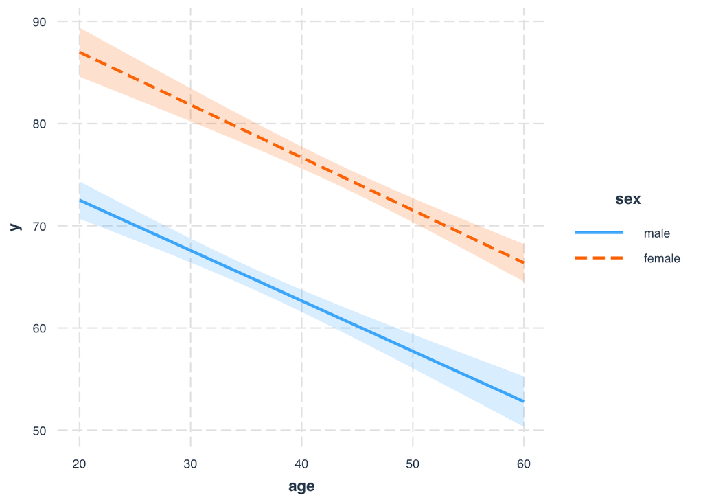

```r
interactions::interact_plot(mod1, pred = age, modx = sex, interval = TRUE)
```

# Missing topics

- `margins ..., atmeans`